# Atlas MEP cells that BoneMarrowMap calls EoBasoMast precursors: a marker check

JN Taroni

2026

## Introduction

In `06_compare-bonemarrowmap-holdout.Rmd`, most of the held-out study’s atlas `megakaryocyte-erythroid progenitor cell` (MEP) cells land on BoneMarrowMap’s `EoBasoMast Precursor`: 0.85 on 10x 5′, and on 3′ 0.44 EoBasoMast plus 0.41 Megakaryocyte Precursor. Is this a naming difference or a mismatch?

- The atlas has no eosinophil/basophil/mast class, so its authors may have put those progenitors in “MEP”.
- Basophil/mast progenitors are known to branch off near the erythroid/megakaryocyte side of the hierarchy, so GATA1+ GATA2+ progenitors could reasonably get either name.

This notebook compares marker genes across groups of cells:

- **Held-out study**, by assay: truth MEP split by BoneMarrowMap broad label; other cells BoneMarrowMap calls EoBasoMast; and comparators (erythroid, HSC, GMP, and monocytes as a negative control).
- **The rest of the atlas:** MEP cells from the other studies, healthy vs AML donors, to see whether the atlas’s MEP label includes basophil/mast progenitors by convention.

How to read it:

- Basophil/mast genes high and erythroid/megakaryocyte genes low in “MEP → EoBasoMast”: the atlas’s “MEP” cells here are largely basophil/mast-committed, and BoneMarrowMap’s name is more specific.
- Erythroid/megakaryocyte genes high and basophil/mast genes low: BoneMarrowMap is mislabeling them.
- Both: a shared progenitor; both names are defensible.

See `.workspace/annotate-aml/bonemarrowmap.md` (step 5).

## Setup

```r
suppressPackageStartupMessages({
  library(dplyr)
  library(ggplot2)
})

holdout_study <- params$holdout_study

root_dir <- rprojroot::find_root(rprojroot::has_dir(".git"))
module_dir <- fs::path(root_dir, "analyses", "annotate-aml")
atlas_file <- fs::path(root_dir, "data", "AML-scAtlas", "AML_scAtlas_le29.h5ad")
bmm_file <- fs::path(
  module_dir, "results", "holdout",
  paste0("bonemarrowmap_predictions_", holdout_study, ".tsv")
)

stopifnot(fs::file_exists(atlas_file), fs::file_exists(bmm_file))

# Plot style shared with the evaluation reports
source(fs::path(module_dir, "utils", "eval-helpers.R"))
theme_set(eval_theme())

# Comparator groups are downsampled to at most this many cells per group and assay
max_cells_per_group <- 500
set.seed(2026)
```

Marker genes, by cell type. All are in the atlas; `FCER1A` (basophil/mast) would belong here but isn’t in the atlas’s gene list.

```r
markers <- list(
  "Eo/Baso/Mast" = c("HDC", "CPA3", "MS4A2", "TPSAB1", "TPSB2", "KIT", "GATA2", "LMO4", "CLC",
                     "PRG2", "EPX", "ENPP3", "HPGDS", "IL5RA", "CEBPE"),
  "Erythroid" = c("GATA1", "KLF1", "TFRC", "CA1", "HBD", "HBB", "CD36", "MYB", "APOC1"),
  "Megakaryocyte" = c("ITGA2B", "PF4", "PPBP", "GP9", "VWF", "GP1BA"),
  "HSPC/GMP" = c("CD34", "CRHBP", "AVP", "MPO", "CTSG")
)
marker_sets <- tibble::tibble(
  gene = unlist(markers, use.names = FALSE),
  marker_set = factor(rep(names(markers), lengths(markers)), levels = names(markers))
)
stopifnot(!anyDuplicated(marker_sets$gene))
```

## Select cells

```r
adata <- anndataR::read_h5ad(atlas_file, as = "HDF5AnnData")
obs <- adata$obs |>
  transmute(
    cell_id = adata$obs_names,
    study = as.character(Study),
    assay = as.character(assay),
    disease = as.character(disease),
    true_fine = as.character(label_fine),
    true_broad = as.character(label_broad)
  )
gene_symbols <- setNames(as.character(adata$var$gene_symbol), adata$var_names)
stopifnot(all(marker_sets$gene %in% gene_symbols))

bmm <- data.table::fread(bmm_file, data.table = FALSE) |>
  select(cell_id, bmm_label, bmm_label_broad)
```

Groups in the held-out study are exclusive, assigned in this order: truth MEP (by BoneMarrowMap broad label), then other cells BoneMarrowMap calls EoBasoMast, then the comparators.

```r
mep <- "megakaryocyte-erythroid progenitor cell"

holdout_cells <- obs |>
  filter(study == holdout_study) |>
  inner_join(bmm, by = "cell_id") |>
  mutate(
    group = case_when(
      true_broad == mep & bmm_label_broad == "EoBasoMast Precursor" ~ "MEP → EoBasoMast",
      true_broad == mep & bmm_label_broad == "Megakaryocyte Precursor" ~ "MEP → Megakaryocyte Precursor",
      true_broad == mep & bmm_label_broad == "MEP" ~ "MEP → MEP",
      true_broad == mep ~ "MEP → other",
      bmm_label_broad == "EoBasoMast Precursor" ~ "other → EoBasoMast",
      true_broad == "erythroid lineage cell" ~ "erythroid lineage cell",
      true_fine == "HSPC:HSC" ~ "HSPC:HSC",
      true_broad == "granulocyte monocyte progenitor cell" ~ "GMP",
      true_broad == "monocyte" ~ "monocyte",
      TRUE ~ NA_character_
    ),
    panel = paste(holdout_study, assay)
  ) |>
  filter(!is.na(group))
stopifnot(nrow(holdout_cells) > 0)

# MEP cells from every other study, by donor disease status
other_mep <- obs |>
  filter(study != holdout_study, true_broad == mep) |>
  mutate(
    group = if_else(disease == "normal", "MEP, healthy donors", "MEP, AML donors"),
    panel = "Atlas MEP, other studies"
  )

group_levels <- c(
  "MEP → EoBasoMast", "MEP → Megakaryocyte Precursor", "MEP → MEP", "MEP → other",
  "other → EoBasoMast", "erythroid lineage cell", "HSPC:HSC", "GMP", "monocyte",
  "MEP, healthy donors", "MEP, AML donors"
)

all_groups <- bind_rows(holdout_cells, other_mep)
```

Cells per group before downsampling, and which other truth labels BoneMarrowMap calls EoBasoMast.

```r
all_groups |>
  count(panel, group) |>
  mutate(group = factor(group, levels = group_levels)) |>
  arrange(panel, group) |>
  knitr::kable()
```

| panel | group | n |
| --- | --- | --- |
| Atlas MEP, other studies | MEP, healthy donors | 1473 |
| Atlas MEP, other studies | MEP, AML donors | 12448 |
| mumme_2023 10x 3’ v3 | MEP → EoBasoMast | 47 |
| mumme_2023 10x 3’ v3 | MEP → Megakaryocyte Precursor | 43 |
| mumme_2023 10x 3’ v3 | MEP → MEP | 10 |
| mumme_2023 10x 3’ v3 | MEP → other | 6 |
| mumme_2023 10x 3’ v3 | other → EoBasoMast | 27 |
| mumme_2023 10x 3’ v3 | erythroid lineage cell | 2259 |
| mumme_2023 10x 3’ v3 | HSPC:HSC | 102 |
| mumme_2023 10x 3’ v3 | GMP | 1439 |
| mumme_2023 10x 3’ v3 | monocyte | 3280 |
| mumme_2023 10x 5’ v1 | MEP → EoBasoMast | 254 |
| mumme_2023 10x 5’ v1 | MEP → Megakaryocyte Precursor | 10 |
| mumme_2023 10x 5’ v1 | MEP → MEP | 24 |
| mumme_2023 10x 5’ v1 | MEP → other | 10 |
| mumme_2023 10x 5’ v1 | other → EoBasoMast | 175 |
| mumme_2023 10x 5’ v1 | erythroid lineage cell | 827 |
| mumme_2023 10x 5’ v1 | HSPC:HSC | 746 |
| mumme_2023 10x 5’ v1 | GMP | 9607 |
| mumme_2023 10x 5’ v1 | monocyte | 7276 |

```r
holdout_cells |>
  filter(group == "other → EoBasoMast") |>
  count(assay, true_fine, sort = TRUE) |>
  knitr::kable()
```

| assay | true_fine | n |
| --- | --- | --- |
| 10x 5’ v1 | HSPC:HSC | 40 |
| 10x 5’ v1 | HSPC:Plasma | 35 |
| 10x 5’ v1 | common myeloid progenitor | 24 |
| 10x 5’ v1 | HSPC:GMP-like | 18 |
| 10x 5’ v1 | HSPC:HSC-like | 11 |
| 10x 5’ v1 | HSPC:B | 9 |
| 10x 5’ v1 | HSPC:GMP | 7 |
| 10x 5’ v1 | HSPC:Prog-like | 7 |
| 10x 3’ v3 | HSPC:Plasma | 6 |
| 10x 3’ v3 | erythroid lineage cell | 6 |
| 10x 5’ v1 | HSPC:cDC-like | 6 |
| 10x 5’ v1 | HSPC:ProB | 4 |
| 10x 5’ v1 | HSPC:Prog | 4 |
| 10x 5’ v1 | granulocyte monocyte progenitor cell | 4 |
| 10x 3’ v3 | HSPC:B | 3 |
| 10x 3’ v3 | common myeloid progenitor | 3 |
| 10x 5’ v1 | erythroid lineage cell | 3 |
| 10x 3’ v3 | HSPC:lateEry | 2 |
| 10x 3’ v3 | granulocyte monocyte progenitor cell | 2 |
| 10x 5’ v1 | HSPC:earlyEry | 2 |
| 10x 3’ v3 | HSPC:HSC | 1 |
| 10x 3’ v3 | HSPC:ProB | 1 |
| 10x 3’ v3 | HSPC:cDC-like | 1 |
| 10x 3’ v3 | HSPC:earlyEry | 1 |
| 10x 3’ v3 | conventional dendritic cell | 1 |
| 10x 5’ v1 | HSPC:LSC | 1 |

```r
other_mep |>
  count(group, study, assay) |>
  knitr::kable()
```

| group | study | assay | n |
| --- | --- | --- | --- |
| MEP, AML donors | jiang_2020 | 10x 3’ v2 | 145 |
| MEP, AML donors | lasry_2022 | 10x 3’ v3 | 9119 |
| MEP, AML donors | li_2022 | 10x 3’ v3 | 11 |
| MEP, AML donors | naldini_2023 | 10x 3’ v2 | 125 |
| MEP, AML donors | naldini_2023 | 10x 3’ v3 | 93 |
| MEP, AML donors | van_galen_2019 | Seq-Well | 18 |
| MEP, AML donors | zhang_2023 | 10x 3’ v2 | 1118 |
| MEP, AML donors | zhang_2023 | 10x 3’ v3 | 1819 |
| MEP, healthy donors | caron_2020 | 10x 3’ v2 | 22 |
| MEP, healthy donors | human_cell_atlas | 10x 3’ v2 | 37 |
| MEP, healthy donors | lasry_2022 | 10x 3’ v3 | 48 |
| MEP, healthy donors | oetjen_2018 | 10x 3’ v2 | 14 |
| MEP, healthy donors | setty_2019 | 10x 3’ v2 | 1304 |
| MEP, healthy donors | van_galen_2019 | Seq-Well | 42 |
| MEP, healthy donors | zhang_2023 | 10x 3’ v3 | 6 |

Downsample to at most 500 cells per group and panel, so the large comparator groups don’t dominate reading the file.

```r
selected <- all_groups |>
  group_by(panel, group) |>
  slice_sample(n = max_cells_per_group) |>
  ungroup()

count(selected, panel, name = "n_selected") |> knitr::kable()
```

| panel | n_selected |
| --- | --- |
| Atlas MEP, other studies | 1000 |
| mumme_2023 10x 3’ v3 | 1735 |
| mumme_2023 10x 5’ v1 | 2473 |

## Expression

Counts for the selected cells, normalized as log1p of counts per 10,000 (library size from all genes), then subset to the marker genes.

```r
keep <- obs$cell_id %in% selected$cell_id
sce <- adata[keep, ]$as_SingleCellExperiment(
  x_mapping = "counts",
  assays_mapping = FALSE,
  colData_mapping = FALSE,
  rowData_mapping = FALSE,
  reducedDims_mapping = FALSE,
  colPairs_mapping = FALSE,
  rowPairs_mapping = FALSE,
  metadata_mapping = FALSE
)
rm(adata)
counts <- as(SummarizedExperiment::assay(sce, "counts"), "CsparseMatrix")
rm(sce)

lib_size <- Matrix::colSums(counts)
marker_ids <- names(gene_symbols)[match(marker_sets$gene, gene_symbols)]
marker_counts <- counts[marker_ids, , drop = FALSE]
rm(counts)
rownames(marker_counts) <- marker_sets$gene

norm <- log1p(t(t(as.matrix(marker_counts)) / lib_size) * 1e4)

expr <- as.data.frame(t(norm)) |>
  mutate(cell_id = colnames(norm)) |>
  tidyr::pivot_longer(-cell_id, names_to = "gene", values_to = "expr") |>
  inner_join(selected |> select(cell_id, panel, group), by = "cell_id")

stopifnot(n_distinct(expr$cell_id) == nrow(selected))
```

```r
dot_data <- expr |>
  group_by(panel, group, gene) |>
  summarize(mean_expr = mean(expr), frac_expr = mean(expr > 0), .groups = "drop") |>
  # scale each gene's mean to its maximum across the groups in a panel
  group_by(panel, gene) |>
  mutate(scaled_mean = if (max(mean_expr) > 0) mean_expr / max(mean_expr) else 0) |>
  ungroup() |>
  left_join(marker_sets, by = "gene") |>
  mutate(
    gene = factor(gene, levels = marker_sets$gene),
    group = factor(group, levels = rev(group_levels))
  )
```

### Dot plot

Color is each gene’s mean expression scaled to its maximum within the panel, so compare colors across rows of the same gene, not across genes. Size is the fraction of cells with any counts.

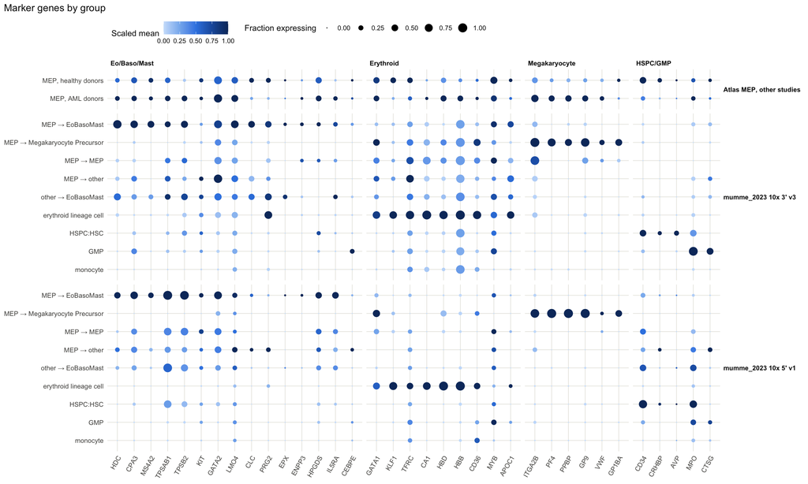

```r
ggplot(dot_data, aes(x = gene, y = group, color = scaled_mean, size = frac_expr)) +
  geom_point() +
  facet_grid(panel ~ marker_set, scales = "free", space = "free") +
  scale_color_gradientn(colors = seq_blue, limits = c(0, 1), name = "Scaled mean") +
  scale_size_area(max_size = 5, limits = c(0, 1), name = "Fraction expressing") +
  labs(x = NULL, y = NULL, title = "Marker genes by group") +
  theme(
    axis.text.x = element_text(angle = 60, hjust = 1),
    strip.text.y = element_text(angle = 0)
  )
```

### Key genes

The fraction of cells expressing a few key genes in each group, for reading exact values.

```r
key_genes <- c("HDC", "CPA3", "MS4A2", "TPSAB1", "CLC", "GATA2", "GATA1", "KLF1", "HBB", "CA1",
               "PF4", "ITGA2B", "CD34")

dot_data |>
  filter(gene %in% key_genes) |>
  mutate(gene = factor(gene, levels = key_genes), group = factor(group, levels = group_levels)) |>
  select(panel, group, gene, frac_expr) |>
  tidyr::pivot_wider(names_from = gene, values_from = frac_expr, names_sort = TRUE) |>
  arrange(panel, group) |>
  knitr::kable(digits = 2)
```

| panel | group | HDC | CPA3 | MS4A2 | TPSAB1 | CLC | GATA2 | GATA1 | KLF1 | HBB | CA1 | PF4 | ITGA2B | CD34 |
| --- | --- | --- | --- | --- | --- | --- | --- | --- | --- | --- | --- | --- | --- | --- |
| Atlas MEP, other studies | MEP, healthy donors | 0.19 | 0.37 | 0.21 | 0.31 | 0.22 | 0.71 | 0.42 | 0.34 | 0.12 | 0.03 | 0.12 | 0.35 | 0.48 |
| Atlas MEP, other studies | MEP, AML donors | 0.21 | 0.29 | 0.14 | 0.30 | 0.06 | 0.80 | 0.33 | 0.05 | 0.34 | 0.07 | 0.39 | 0.61 | 0.17 |
| mumme_2023 10x 3’ v3 | MEP → EoBasoMast | 0.83 | 0.64 | 0.51 | 0.36 | 0.49 | 0.72 | 0.11 | 0.09 | 0.87 | 0.19 | 0.00 | 0.30 | 0.04 |
| mumme_2023 10x 3’ v3 | MEP → Megakaryocyte Precursor | 0.00 | 0.05 | 0.00 | 0.00 | 0.02 | 0.44 | 0.49 | 0.07 | 0.95 | 0.44 | 0.74 | 0.98 | 0.05 |
| mumme_2023 10x 3’ v3 | MEP → MEP | 0.10 | 0.10 | 0.00 | 0.30 | 0.00 | 0.60 | 0.40 | 0.10 | 1.00 | 0.70 | 0.00 | 0.90 | 0.00 |
| mumme_2023 10x 3’ v3 | MEP → other | 0.17 | 0.33 | 0.00 | 0.33 | 0.33 | 0.83 | 0.33 | 0.17 | 0.83 | 0.33 | 0.00 | 0.33 | 0.00 |
| mumme_2023 10x 3’ v3 | other → EoBasoMast | 0.56 | 0.30 | 0.22 | 0.33 | 0.41 | 0.59 | 0.22 | 0.00 | 0.89 | 0.33 | 0.00 | 0.15 | 0.07 |
| mumme_2023 10x 3’ v3 | erythroid lineage cell | 0.10 | 0.01 | 0.02 | 0.04 | 0.00 | 0.38 | 0.66 | 0.66 | 0.99 | 0.95 | 0.01 | 0.29 | 0.06 |
| mumme_2023 10x 3’ v3 | HSPC:HSC | 0.00 | 0.12 | 0.00 | 0.10 | 0.01 | 0.13 | 0.01 | 0.02 | 0.87 | 0.10 | 0.00 | 0.00 | 0.48 |
| mumme_2023 10x 3’ v3 | GMP | 0.01 | 0.33 | 0.01 | 0.09 | 0.00 | 0.08 | 0.00 | 0.05 | 0.76 | 0.06 | 0.00 | 0.02 | 0.11 |
| mumme_2023 10x 3’ v3 | monocyte | 0.01 | 0.00 | 0.00 | 0.00 | 0.00 | 0.01 | 0.02 | 0.01 | 0.89 | 0.26 | 0.01 | 0.01 | 0.00 |
| mumme_2023 10x 5’ v1 | MEP → EoBasoMast | 0.44 | 0.65 | 0.31 | 0.97 | 0.08 | 0.71 | 0.15 | 0.00 | 0.05 | 0.00 | 0.00 | 0.06 | 0.22 |
| mumme_2023 10x 5’ v1 | MEP → Megakaryocyte Precursor | 0.00 | 0.00 | 0.00 | 0.00 | 0.00 | 0.20 | 0.60 | 0.10 | 0.10 | 0.00 | 1.00 | 0.90 | 0.00 |
| mumme_2023 10x 5’ v1 | MEP → MEP | 0.04 | 0.38 | 0.00 | 0.67 | 0.00 | 0.54 | 0.29 | 0.08 | 0.04 | 0.00 | 0.00 | 0.04 | 0.38 |
| mumme_2023 10x 5’ v1 | MEP → other | 0.20 | 0.40 | 0.10 | 0.40 | 0.10 | 0.50 | 0.00 | 0.00 | 0.00 | 0.00 | 0.00 | 0.20 | 0.20 |
| mumme_2023 10x 5’ v1 | other → EoBasoMast | 0.11 | 0.26 | 0.03 | 0.91 | 0.01 | 0.31 | 0.03 | 0.00 | 0.07 | 0.01 | 0.01 | 0.01 | 0.47 |
| mumme_2023 10x 5’ v1 | erythroid lineage cell | 0.00 | 0.00 | 0.00 | 0.00 | 0.00 | 0.01 | 0.54 | 0.75 | 1.00 | 0.69 | 0.00 | 0.01 | 0.02 |
| mumme_2023 10x 5’ v1 | HSPC:HSC | 0.00 | 0.07 | 0.00 | 0.67 | 0.00 | 0.15 | 0.00 | 0.00 | 0.07 | 0.00 | 0.00 | 0.01 | 0.80 |
| mumme_2023 10x 5’ v1 | GMP | 0.00 | 0.00 | 0.00 | 0.03 | 0.00 | 0.01 | 0.00 | 0.01 | 0.04 | 0.00 | 0.00 | 0.07 | 0.15 |
| mumme_2023 10x 5’ v1 | monocyte | 0.00 | 0.01 | 0.00 | 0.01 | 0.00 | 0.00 | 0.00 | 0.00 | 0.05 | 0.00 | 0.00 | 0.00 | 0.01 |